# Data organization in spreadsheets

Bianca Peterson (PhD)

[figure not shown]

### Data Organization in Spreadsheets

This presentation is based on the [Data Carpentry Spreadsheet Ecology Lesson](http://www.datacarpentry.org/spreadsheet-ecology-lesson/)

### Introduction

- Good data organization is the foundation of any research project
- Structure data the way that computers need it
- Much of your time will be spent in this 'data wrangling' stage

### In this lesson, you will learn:

- Good data entry practices - formatting data tables in spreadsheets
- How to avoid common formatting mistakes
- Approaches for handling dates in spreadsheets
- Basic quality control and data manipulation in spreadsheets
- Exporting data from spreadsheets

### Questions

- How many people have used spreadsheets in their work?
- What kind of operations do you do in spreadsheets?
- Which ones do you think spreadsheets are good for?
- How many people have accidentally done something that made them frustrated or sad?

### We can use spreadsheets for:

- Data entry
- Organizing data
- Subsetting and sorting data
- Statistics
- Plotting

### Problems with spreadsheets:

- Generating tables for publications in a spreadsheet is not optimal
- The graphical, drag and drop nature of spreadsheet programs makes it very difficult, if not impossible, to replicate your steps
- When doing calculations in a spreadsheet, it's easy to accidentally apply a slightly different formula to multiple adjacent cells

### Using spreadsheets for data entry and cleaning

- Clean data prior to importation into a statistical analysis program
- Check your data quality
- Produce preliminary summary statistics

### Formatting data tables in spreadsheets

- Most common mistake: rely on context, notes in the margin, spatial layout of data and fields to convey information
- Humans can (usually) interpret these things, but computers don't view information the same way
- We have to set up our data for the computer to understand it in order to analyze it fast and efficiently

### Keeping track of your analyses

- Don't modify original dataset
- Create a new file/tab with cleaned/analyzed data
- Keep track of steps used for data cleaning/analysis

### Structuring data in spreadsheets

- Put all variables in columns
- Put each observation in its own row
- Don't combine multiple pieces of information in one cell
- Leave raw data raw - don't change it!
- Export cleaned data to text-based format (CSV) - anyone can use the data and it is required by most data repositories

### Data: Chihuahuan desert ecosystem

- S. K. Morgan Ernest, Thomas J. Valone, and James H. Brown. 2009. Long-term monitoring and experimental manipulation of a Chihuahuan Desert ecosystem near Portal, Arizona, USA. Ecology 90:1708.
  - http://esapubs.org/archive/ecol/E090/118/
  - Data files: rodents, plants, ants, precipitation
- We will be using a modified tabular dataset of observations of small mammals
- It provides a real world example of life-history, population, and ecological data, with sufficient complexity to teach many aspects of data analysis and management, but some complexities have been removed for teaching purposes

### Data: Chihuahuan desert ecosystem

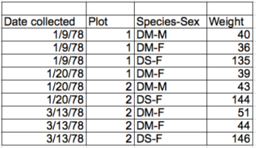

- Variables: date collected, plot, species, sex and weight
- Problem: species and sex in the same field
- Thus not able to look at a single species or look at different weight distributions by sex

### Let's look at a messy version of the data

Download the data from FigShare: https://ndownloader.figshare.com/files/2252083

- Two tabs: 2 field assistants conducted surveys, one in 2013 and one in 2014
- Identify what is wrong with this spreadsheet
- Discuss the steps you would need to take to clean up the data and put them all together in one spreadsheet

### Common spreadsheet errors: using multiple tables

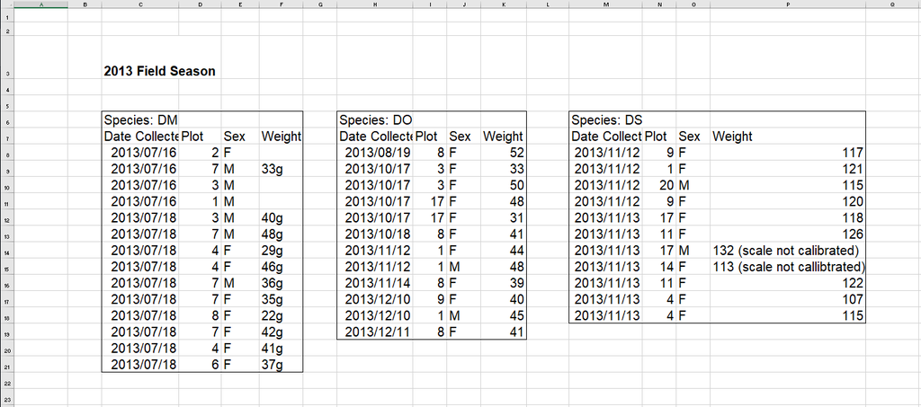

- This confuses the computer
- You're drawing false associations between things for the computer, which sees each row as an observation
- You're potentially using the same field name in multiple places, which makes it harder to clean the data up into a usable form

### Common spreadsheet errors: using multiple tabs

- The computer will not be able to see connections in the data
- You are more likely to accidentally add inconsistencies to your data when recording data in a new tab every time
- This will add an extra step for yourself, because data will need to be combined before analyzing it
- Ask yourself: Can I avoid adding a new tab by adding another column to the original spreadsheet?
- The data sheet may get very long - freeze column headers so that they remain visible

### Common spreadsheet errors: not filling in zeros

- There's a difference between a zero and a blank cell
- Zero = actual data | blank cell = no measurement
- Missing/null/unknown values can cause problems with subsequent calculations or analyses

### Common spreadsheet errors: using problematic null values

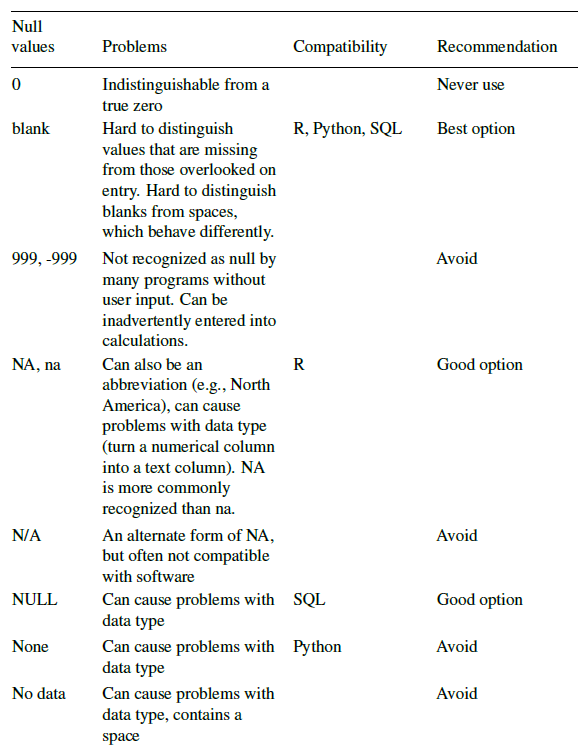

Article: Nine simple ways to make it easier to (re)use your data by White et al., 2013 https://peerj.com/preprints/7/

### Common spreadsheet errors: using formatting to convey information

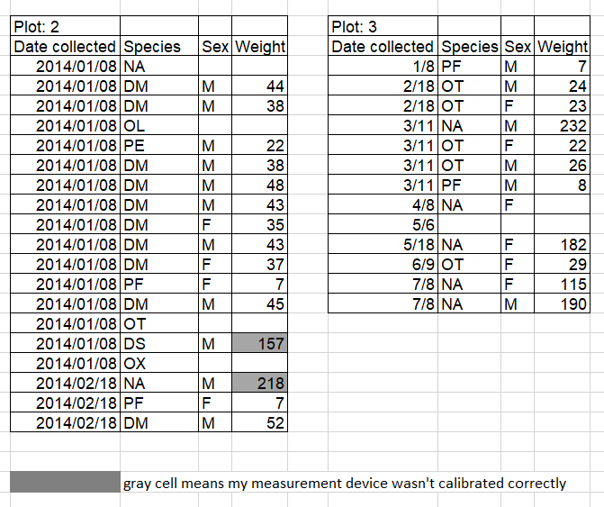

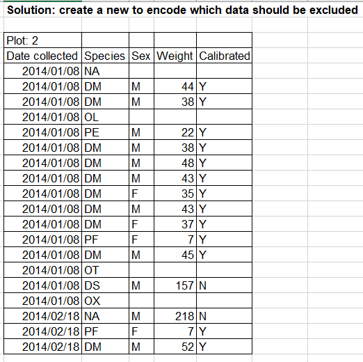

### Common spreadsheet errors: using formatting to make the data sheet look pretty

- Example: merging cells
- Solution: restructure your data in such a way that you will not need to merge cells to organize your data

### Common spreadsheet errors: placing comments or units in cells

- Solution: create another field to add notes or units to cells

### Common spreadsheet errors: entering more than one piece of information in a cell

- Solution: create another column to record all the information you need

### Common spreadsheet errors: using problematic field names

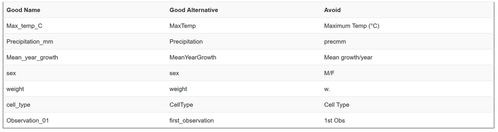

### Common spreadsheet errors: using problematic field names

- Solution:
  - choose descriptive field names
  - do not include spaces, numbers, or special characters of any kind
- Spaces can be misinterpreted by parsers that use whitespace as delimiters
- Some programs don't like field names that are text strings that start with numbers
- Underscores (_) are a good alternative to spaces
- Consider writing names in camel case (like this: ExampleFileName) to improve readability

### Common spreadsheet errors: using special characters in data

- Examples:
  - line breaks when writing longer text in a cell
  - when copying data in from other applications such as Word
  - using fancy non-standard characters (such as left- and right-aligned quotation marks)
- Solution: avoid adding characters such as newlines, tabs, and vertical tabs; only use text and spaces

### Common spreadsheet errors: inclusion of metadata in data table

- Example: adding legends to the top or bottom of your data table to explain column meaning, units, exceptions, etc.
- Solution: recording data about your data (“metadata”) is essential, but should not be contained in the data file itself
- Your future self and other people may want to examine or use your data to understand your findings, verify your findings, review your submitted publication, replicate your results, design a similar study, or archive your data for access and re-use
- Store metadata as a separate plain text file in the same directory as your data file

### Dates as data

- Not best practice to store dates in a single column
- According to your computer's settings…
- Excel is unable to parse dates from before 1899-12-31 (referred to as the 1900 date system) - be careful if you're working with historical data
- Alternatively, Excel may use the 1904 date system where a different serial number is assigned
- Be careful when exporting data from Excel - dates may be ~4 years off!
- Store MONTH, DAY and YEAR in separate columns

### Quality assurance/control

- Quality assurance versus Quality control
- Quality assurance = techniques implemented prior to entering data
- Quality control = techniques used after entering data to check for errors

### Quality assurance

- Only allow valid values during data entry by using Data Validation (Excel) or Validity (Libre Office)

[figure not shown]

### Quality control: Sorting

Download the semi-cleaned data file: https://ndownloader.figshare.com/files/8015254

- Sorting - bad values often sort to the bottom or top of the column (sort data by each field, one at a time)
- On the Data tab, click on the AZ sort button
- Remember to expand your sort to prevent data corruption, i.e. all the data in one row should move together

### Quality control: Conditional formatting

- Conditional formatting - color code values by some criteria or lowest to highest
- This makes it easy to scan your data for outliers
- In the main Excel menu bar, click Format > Conditional Formatting… > +
- Apply a 2-Color-Scale formatting rule to the Weight_grams column, with lowest values set to orange and highest values set to yellow
- What do you see?

### Exporting data

Storing data in Excel default file format (*.xls or *.xlsx) isn't a good idea, because…

- It's proprietary format - in future it might become inconvenient/impossible to open the file
- Other spreadsheet software may not be able to open files in this format
- Different versions of Excel may handle data differently, leading to inconsistencies
- More journals and grant agencies are requiring data to be deposited in a data repository, and most of them don't accept Excel format
- Use tabs as delimiter (.tsv file) when the data contains commas

### Key points

- Good data organization is the foundation of any research project
- Never modify your raw data - always make a copy before making any changes
- Keep track of all the steps you take to clean your data
- Organize your data according to tidy data principles
- Have a look at Hadley Wickhams' manuscript about Tidy Data: https://www.jstatsoft.org/article/view/v059i10
- Use one column for one variable
- Use one row for one observation
- Use one cell for one value

### Key points

- Don't use multiple tables in one sheet
- Don't use multiple tabs in a file
- Fill in zero when you mean zero
- Use a blank cell to indicate a null value
- Don't use formatting to convey information or make the data look pretty
- Don't put units or comments in cells
- Don't combine several values in one cell
- Take care over column names

### Key points

- Avoid including special characters in your data file
- Put metadata (units, legends etc.) in a separate file
- Excel is notoriously bad at handling dates.
- Dates can be stored more robustly as YEAR, MONTH, DAY or YEAR, DAY-OF-YEAR in separate columns.
- Use data validation tools to minimise the possibility of input errors.
- Use sorting and conditional formatting to identify possible errors.
- Use .csv file format for data storage and processing
- Be careful when using commas in values